# Delo s podatki

## Branje podatkov

- Podatke pridobivamo iz različnih virov (tekstovni formati in datoteke, CSV, Excel, splet, podatkovne baze, …)
- Tipično nas zanimajo tabelarični podatki.
- Oglejmo si razpredelnico v Excelu.

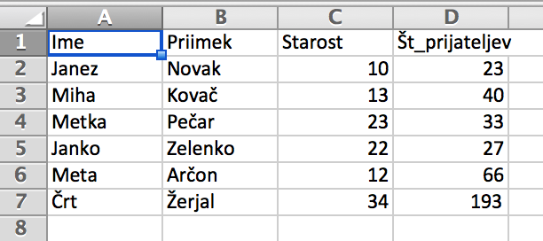

- Potrebujemo paketa `readxl` ter `openxlsx`.
- `Tools -> Install packages`
- Nalaganje paketa (podobno `import <ime_paketa>` v Pythonu)

```r
> library("readxl")
> library("openxlsx")
```

## Branje podatkov iz Excela

- Najbolje, da delovno področje nastavimo na mapo, kjer je Excelova datoteka.
- V našem primeru, bo datoteka v podmapi `viri`.

```r
> podatki <- read_xlsx("viri/primer.xlsx")
> print(podatki)
# A tibble: 6 x 4
  Ime   Priimek Starost Št_prijateljev
  <chr> <chr>     <dbl>          <dbl>
1 Janez Novak        10             23
2 Miha  Kovač        13             40
3 Metka Pečar        23             33
4 Janko Zelenko      22             27
5 Meta  Arčon        12             66
6 Črt   Žerjal       34            193
```

- Lahko podamo tudi specifičen list (ang. sheet) v Excelovi datoteki

```r
> podatki <- read_xlsx("viri/primer.xlsx", sheet="List1")
```

## Dodajanje stolpca

- Izračunajmo povprečno število prijateljav na leto življenja.

```r
> podatki$Št_prijateljev/podatki$Starost
[1] 2.300000 3.076923 1.434783 1.227273 5.500000 5.676471
```

- Dodajmo rezultat v razpredelnico kot nov stolpec (podobno kot kopiranje formule pri Excelu).

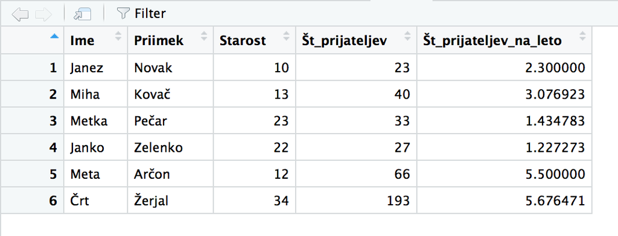

```r
> podatki$Št_prijateljev_na_leto <- podatki$Št_prijateljev/podatki$Starost
> View(podatki)
```

- namesto `podatki$ime` bi lahko pisali `podatki["ime"]`

## Knjižnica `dplyr`

- Omogoča enostavnejše in preglednejše operacije na razpredelnicah.
- Uvaja operator ‘veriženja’, ki omogoča preglednejši opis operacij brez gnezdenja funkcij.
- `f(a, b, ...)` zapišemo v obliki `a %>% f(b, ...)`.
- Rezultat prejšnjega izraza se postavi za prvi argument funkcije naslednjega izraza, ki ga ni potrebno navajati.
- Uvoz

```r
> library(dplyr)
```

- Primer

```r
> View(podatki)
> podatki %>% View()
> podatki %>% View
```

- Pozor: funkcije iz paketa `dplyr` za delo na razpredelnicah vedno kot prvi argument jemljejo razpredelnico in vedno vračajo novo razpredelnico (ne spreminjajo obstoječe)!

## Popravljanje stolpca

- Popravimo dodani stolpec tako, da ga zaokrožimo na dve decimalki.

```r
> podatki$Št_prijateljev_na_leto <- round(podatki$Št_prijateljev_na_leto, 2)
```

- Stolpec (ali več stolpcev) preberemo kot vektor in ga prepišemo.
- Alternativno z `dplyr`:

```r
> podatki <- podatki %>%
       mutate(Št_prijateljev_na_leto=round(Št_prijateljev/Starost, 2))
```

- Pozor: `dplyr` nam olajša delo, saj imena stolpcev preprosto navedemo kot dejanska imena in z njimi lahko neposredno računamo.
- Pomembno: če zapis veriženja napišemo v večih vrsticah, mora biti operator `%>%` pred prelomom vrstice.

## Brisanje stolpca

- Stolpec `Priimek` želimo odstraniti.

```r
> priimki <- podatki$Priimek  # shranimo stolpec v vektor
> podatki$Priimek <- NULL
> podatki %>% View
```

- Če v stolpec zapišemo `NULL`, ga zbrišemo.
- Pozor: če v stolpec zapišemo `0`, ga nastavimo na vrednost `0`!
- Z `dplyr`:

```r
> podatki2 <- podatki %>% select(-Priimek)
```

- Funkcija `select` izbere stolpce. Če je stolpec predznačen z `'-'`, to povzroči odstranjevanje tega stolpca v rezultatu.

## Vstavljanje stolpca

- Dodajanje/vstavljanje stolpca

```r
> podatki$Priimek <- priimki
> podatki %>% View
```

- Alternativno (`dplyr`)

```r
> podatki2 %>% mutate(Priimek=priimki)
```

- Stolpec se doda na zadnje mesto.
- Če razpredelnic ne izpisujemo, vrstni red stolpcev načeloma ni važen.

## Preurejanje stolpcev

- Novo dodani stolpec želimo prestaviti na 2. mesto.
- Preureditev stolpcev izvedemo z operatorjem `[]` za podzaporedja, ki pa vrne novo razpredelnico.

```r
> podatki[c(1,5,2,3,4)]
```

- Če želimo preurediti isto razpredelnico, ji priredimo dobljeno razpredelnico.

```r
> podatki <- podatki[c(1,5,2,3,4)]
```

## Izbor določenih stolpcev

- Z operatorjem za podzaporedja lahko naredimo novo razpredelnico z izbranimi stolpci.

```r
> podatki[c("Ime", "Št_prijateljev")]
```

- Namesto indeksov smo uporabili kar imena stolpcev.
- Alternativno (`dplyr`) lahko uporabimo funkcijo `select`:

```r
> podatki %>% select(Ime, Št_prijateljev)
```

## Preimenovanje stolpca

- Stolpec `Št_prijateljev` bi radi preimenovali v `st_prijateljev`.

```r
> names(podatki)[4] <- "st_prijateljev"
> podatki %>% names
[1] "Ime"                    "Priimek"                "Starost"
[4] "st_prijateljev"         "Št_prijateljev_na_leto"
```

- Alternativno (`dplyr`) lahko uporabimo funkcijo `rename`:

```r
> podatki <- podatki %>% rename(st_prijateljev=Št_prijateljev)
```

## Filtriranje vrstic

- Vsi, ki so stari vsaj 15 let.

```r
> podatki[podatki$Starost >= 15, ]
```

- Imena vseh, ki so stari med 15 in 30 let.

```r
> podatki[podatki$Starost >= 15 & podatki$Starost <= 30, c("Ime")]
```

- Alternativno (`dplyr`) lahko uporabimo funkcijo `filter`:

```r
> podatki %>% filter(Starost >= 15)
> podatki %>% filter(Starost >= 15 & Starost <= 30) %>% select(Ime)
```

## Preurejanje vrstic

- Kako bi morali urediti indekse, da bi bile vrstice razporejene po starosti?

```r
> podatki$Starost
[1] 10 13 23 22 12 34
> order(podatki$Starost)
[1] 1 5 2 4 3 6
```

- Prerazporejene indekse uporabimo za prerazporeditev v urejen vrstni red.

```r
> novi <- podatki[order(podatki$Starost), ]
```

- Alternativno (`dplyr`) lahko uporabimo funkcijo `arrange`:

```r
> podatki %>% arrange(Starost)
> podatki %>% arrange(desc(Starost)) # obratni vrstni red
```

## Shranjevanje v Excelovo datoteko

- Uporabimo knjižnico `openxlsx`, ter funkcijo `write.xlsx`.

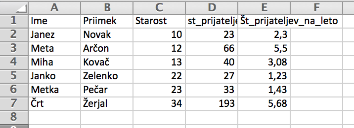

```r
> library("openxlsx")
> write.xlsx(novi, "viri/primer2.xlsx")
```

- Zaporedje vseh (efektivnih) transformacij lahko s pomočjo veriženja napišemo takole:

```r
read_xlsx("viri/primer.xlsx") %>%
       mutate(Št_prijateljev_na_leto=round(Št_prijateljev/Starost, 2)) %>%
       rename(st_prijateljev=Št_prijateljev) %>%
       arrange(Starost) %>%
       write.xlsx("viri/primer2.xlsx")
```

## Razmejeni tekstovni format (CSV)

- Podatke velikokrat dobimo v tekstovni obliki, v razmejenem formatu
  - vsaka vrstica v ločeni vrstici,
  - celice so razmejene s posebnim znakom (ang. delimiter). Tipično je to podpičje, vejica, presledek, tabulator, …
  - decimalna vejica ali pika,
  - tekstovne celice so v dvojnih navednicah,
  - paziti moramo na kodne tabele (kot pri tekstovnih datotekah v Pythonu),
- CSV (ang. Comma separated values)
  - pogost format,
  - ameriški (separator je vejica, decimalna pika) in evropski (separator je podpičje, decimalna vejica),
  - možen izvoz lista iz Excela

## Razmejeni tekstovni format (CSV)

- Branje - branje - paket `readr`
  - `read_delim` - sami konfiguriramo razmejitveni znak
  - `read_csv` - ameriški CSV
  - `read_csv2` - evropski CSV
- Ekvivalentne funkcije za pisanje: `write.table`, `write.csv`, `write.csv2`, privzeto vgrajene v R
- Primer: zapis razpredelnice v CSV datoteko v evropskem formatu

```r
> podatki %>% write.csv2("viri/primer2.csv",fileEncoding = "utf8")
```

- Branje:

```r
> prebrani <- read_csv2("viri/primer2.csv")
> prebrani %>% View
```